# Stat 579 - Homework #4

9/18/2018

## Subsets and Visualizations: Movie Mojo

For this homework we are using the data set `mojo` from the classdata package. `mojo` constains data on box office revenue for movies based on the website https://www.boxofficemojo.com .

Run the following two commands to install the newest version of the package from github:

```r
library(devtools) # error? then run install.packages("devtools")
install.packages("devtools")
devtools::install_github("heike/classdata")
```

Check what is in the data set:

```r
library(classdata)
head(mojo)
```

```
##   TW LW                         Title Studio Weekend Gross % Change
## 1  1  1             Crazy Rich Asians     WB      21964345    -11.5
## 2  2  2                       The Meg     WB      10535459    -17.8
## 3  3  4 Mission: Impossible - Fallout   Par.       7032499    -13.0
## 4  4 22                     Searching   SGem       6066463   1460.4
## 5  5 NA              Operation Finale    MGM       6022758       NA
## 6  6  6    Disney's Christopher Robin     BV       5277955    -15.7
##   Theater Count Theater Change Average Total Gross Budget (in Million)
## 1          3865            339    5683   110691733                  30
## 2          3761           -270    2801   120521875                 130
## 3          2639           -413    2665   204379028                 178
## 4          1207           1198    5026     6574943                  NA
## 5          1818             NA    3313     7749853                  24
## 6          2925           -469    1804    85686823                  NA
##   Week                     Weekend Year WeekNo
## 1    3 August 31-September 2, 2018 2018     35
## 2    4 August 31-September 2, 2018 2018     35
## 3    6 August 31-September 2, 2018 2018     35
## 4    2 August 31-September 2, 2018 2018     35
## 5    1 August 31-September 2, 2018 2018     35
## 6    5 August 31-September 2, 2018 2018     35
```

```r
tail(mojo)
```

```
##       TW LW                      Title Studio Weekend Gross % Change
## 31713 90 77               Now, Forager  Argo.           405    -72.5
## 31714 91 85           The Waiting Room   ICir           290      8.2
## 31715 92 82        Beware of Mr. Baker     SF           284    -53.3
## 31716 93 NA                    Citadel  Cdgm.           206       NA
## 31717 94 NA Jason Becker: Not Dead Yet     KL           200       NA
## 31718 95 80                    Smashed    SPC           186    -79.1
##       Theater Count Theater Change Average Total Gross Budget (in Million)
## 31713             1             NA     405       10896                  NA
## 31714             1             NA     290      176277                  NA
## 31715             1             NA     284       53371                  NA
## 31716             1             NA     206       13201                  NA
## 31717             1             NA     200        1294                  NA
## 31718             3             -2      62      375981                  NA
##       Week           Weekend Year WeekNo
## 31713   14 January 4-6, 2013 2013      1
## 31714   15 January 4-6, 2013 2013      1
## 31715    6 January 4-6, 2013 2013      1
## 31716    9 January 4-6, 2013 2013      1
## 31717    3 January 4-6, 2013 2013      1
## 31718   13 January 4-6, 2013 2013      1
```

2. What is the difference between the variables `Week` and `WeekNo`? Describe in your words.

```r
?mojo
```

week is the movie that has been in thearters. weekno is the week number of the year(1 through 52 or 53)

3. Use `ggplot2` to plot total gross (`Total Gross`) against week number (`WeekNo`). Facet by Year. Interpret the result.

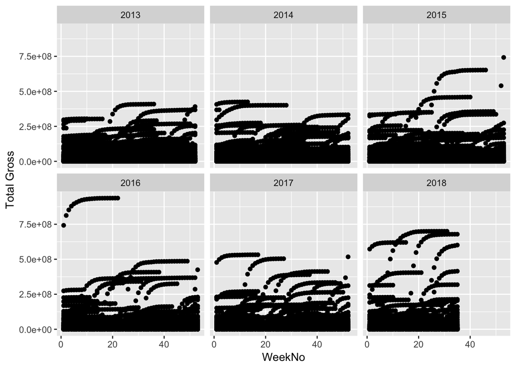

```r
library(ggplot2)
ggplot(mojo, aes(WeekNo, `Total Gross`))+
  geom_point()+
  facet_wrap(~Year)
```

```r
# Which movie had the highest total gross over the time frame?
library(dplyr)
mojo$Title[which.max(mojo$`Total Gross`)]
```

```
## [1] "Star Wars: The Force Awakens"
```

```r
# How many weeks was that movie on rank 1?  5
a=filter(mojo, Title=="Star Wars: The Force Awakens", TW==1)
nrow(a)
```

```
## [1] 5
```

```r
# How long was it in box offices overall?  24
b=mojo$Week[which(mojo$Title=="Star Wars: The Force Awakens")]
max(b)
```

```
## [1] 24
```

4. Pick two movies that were in box office some time between 2013 and 2018 and find the corresponding data in the `mojo` data. How does total gross of the two movies compare? Draw a plot and comment on the result.

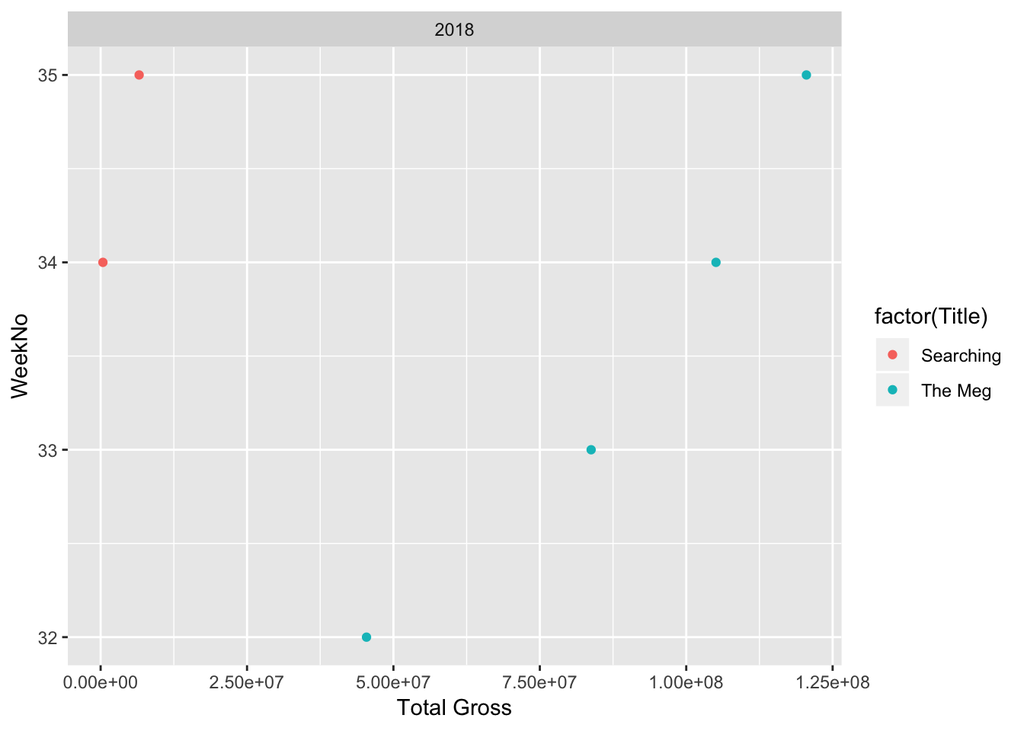

```r
a=filter(mojo, Title=="The Meg" | Title=="Searching")
ggplot(a, aes(`Total Gross`, WeekNo))+
  geom_point(aes(colour=factor(Title)))+
  facet_wrap(~Year)
```

5. Hit or Flop? The variable `Budget (in Million)` contains estimated budget numbers for some movies. For how many movies is this information available (careful! trick question - look at what the function `unique` does)? Studios would like to see their budget returned by the opening weekend. What is the percentage of movies for which that happened? How many movies did not have their budget matched in total gross by the third weekend? For each of these two questions describe your ‘plan of attack’, i.e. lay out how you go about finding an answer to the question. Identify one movie, that did not match its budget by week 3. Plot the incurred loss over time.

```r
# Studios would like to see their budget returned by the opening weekend.???????????????????????? What is the percentage of movies for which that happened?

mojoNew <- mojo[!is.na(mojo$`Budget (in Million)`),!colnames(mojo) %in% c("Year", "WeekNo")]
mojoNew <- unique(mojoNew)

a=filter(mojoNew, Week==1, `Total Gross`/1000000 > `Budget (in Million)`)$Title
b=filter(mojoNew, Week==1)$Title
ratio1=110/630
ratio1
```

```
## [1] 0.1746032
```

```r
# How many movies did not have their budget matched in total gross by the third weekend?
c=filter(mojoNew, Week==3, `Total Gross`/1000000 < `Budget (in Million)`)$Title
d=filter(mojoNew, Week==3)$Title
ratio3=320/626
ratio3
```

```
## [1] 0.5111821
```

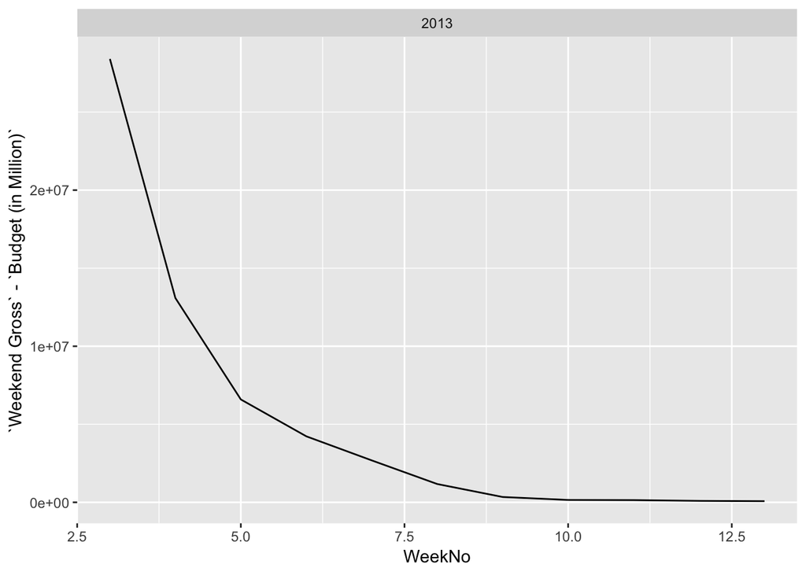

```r
#  Identify one movie, that did not match its budget by week 3.Plot the incurred loss over time.

mojo %>%
  filter( Title == "Mama") %>%
ggplot(aes(x=WeekNo, y=`Weekend Gross`-`Budget (in Million)`))+
  geom_line()+
  facet_wrap(~Year)
```